# Homework2

## NLP: Homework 2

### Patricia Goresen

#### 1/28/19

```python
import nltk
import urllib.request as urllib2
from bs4 import BeautifulSoup
import string
from lexical_diversity import lex_div as ld
```

### Load Books

```python
# get home url
base_url = "http://www.gutenberg.org/wiki/Children%27s_Instructional_Books_(Bookshelf)"
# fetch page
webpage = urllib2.urlopen(base_url)

# create soup object
soup = BeautifulSoup(webpage, "html.parser")
```

```python
# get list of tags
taglist = []
for tag in soup.find_all(True):
    taglist.append(tag.name)
print(set(taglist))
```

```
{'span', 'html', 'body', 'img', 'a', 'script', 'fieldset', 'p', 'title', 'h5', 'ul', 'div', 'hr', 'form', 'h1', 'input', 'h3', 'meta', 'link', 'h2', 'head', 'li', 'br', 'i'}
```

```python
# filter soup object
#soup.find_all("body")
ul = soup.find_all("ul")
#ul
```

```python
# get graded reader section
readers = ul[3]
```

```python
#readers
```

```python
#readers.find_all("a")[0]
#readers.find_all("a")[1]
#readers.find_all("a")[2]
#readers.find_all("a")[3]
## we want class 'extiw'
```

```python
# now we have all the books
books = readers.find_all("a", class_="extiw")
```

```python
# now let's get list with names and urls
#for link in books:
#    print(link.get('href'))
#    print(link.get('title'))
```

```python
# create dictionary with title and url
book_list = {}
for link in books:
    book_list["".join(link.contents)] = "http:" + link.get('href')
```

```python
# now we want to get link to books
for title,url in book_list.items():
    webpage = urllib2.urlopen(url)
    soup = BeautifulSoup(webpage, "html.parser")
    books = soup.find_all("a")
    for i,link in enumerate(books):
        #need link with read this book...
        if "Read this book online" in str(link.contents):
            book_list[title] = "http:" + link.get('href')

#book_list
##now we have a dictionary with titles and urls
```

```python
def cleanText(link):
    webpage = urllib2.urlopen(link).read()
    soup = BeautifulSoup(webpage, 'html.parser')
    book = soup.getText(strip = True)
    # Delete HTML Tags
    book = BeautifulSoup(book, "lxml").text
    #start and stop
    if book.find("CONTENTS") > -1:
        beginning = book.find("CONTENTS")
    else:
        beginning = book.find("START OF ")
    end = book.find("End of the Project Gutenberg EBook")
    book = book[beginning:end]
    #Convert to lower case
    book = book.lower()
    #replace special characters with space
    book = book.replace('\r', ' ').replace('\n', ' ').replace("," , " ").replace(".", " ").replace("!", " ").replace('"', " ").replace("—", " ").replace("-", " ")
    #Delete page numbers and other characters
    book = "".join([x for x in book if 96 < ord(x) < 123 or ord(x) == 32])
    #split on spaces
    book = book.split(" ")
    return book
```

```python
# pull cleaned books
for title,link in book_list.items():
    book_list[title] = cleanText(link)
```

```python
#book_list.keys()
```

[output not shown]

```python
#Clean up Titles
book_list["Parker's Second Reader"] = book_list.pop("Parker's Second Reader \nNational Series of Selections for Reading, Designed For The Younger Classes In Schools, Academies, &C.")
```

```python
def vocabMeasures(book, stat):
    if stat == 'token':
        token = len(book)
        return token
    elif stat == 'vocab':
        vocab = len(set(book))
        return vocab
    elif stat == 'long_num':
        words = set(book)
        long_words = [w for w in words if len(w) > 10]
        numLongWords = len(long_words)
        return numLongWords
    elif stat == 'lex_div':
        lex_div = len(set(book)) / len(book)
        return lex_div
    elif stat == 'ttr':
        ttr = ld.ttr(book)
        return ttr
    else:
        mtld = ld.mtld(book)
        return mtld
```

## 1. In Python, create a method for scoring the vocabulary size of a text, and normalize the score from 0 to 1. It does not matter what method you use for normalization as long as you explain it in a short paragraph. (Various methods will be discussed in the live session.)

The vocabulary size of a text is the count of *unique* words in a text, or the unique set of tokens in a text. The vocabulary size of the Gutenburg books were normalized using the following equation: $$ \frac{(x- minX)}{(maxX - minX)} $$ where x is the vocabulary size of the book, minX is the smallest vocabulary size of all books in the set, and maxX is the biggest vocabulary size of all books. Normalization is used when to adjust a broad range of values to a common scale. This specific normalization method was used because this ensures the range will be [0,1] where 0 will be the smallest value and 1 will be the largest value. Additionally, every value will be scaled according to the min and max. This makes the values scale and more intuitive. This method of normalization is one of the most widely used.

```python
vocabStats = {}
for k,v in book_list.items():
    vocabStats[k] = vocabMeasures(v, 'vocab')
```

```python
normVocabStats = {}
maxVocab = max(vocabStats.values())
minVocab = min(vocabStats.values())
normVocabStats = {k: (v-minVocab) / (maxVocab-minVocab) for k, v in vocabStats.items()}
```

```python
for key, value in sorted(normVocabStats.items(), key=lambda x: x[1]):
    print("{} : {}".format(key, value))
```

```
New National First Reader : 0.0
McGuffey's First Eclectic Reader, Revised Edition : 0.022764873271126994
The Ontario High School Reader : 0.08179471907881676
The Beacon Second Reader : 0.12004500033088479
McGuffey's Second Eclectic Reader : 0.12209648600357356
Story Hour Readers — Book Three : 0.12719211170670372
Sanders' Union Fourth Reader : 0.13116272913771423
McGuffey's Third Eclectic Reader : 0.17014095691880088
The Child's World Third Reader : 0.19151611408907418
Parker's Second Reader : 0.28032559062934287
New National Fourth Reader : 0.45741512805241213
De La Salle Fifth Reader : 0.45973132155383495
The Ontario Readers: Third Book : 0.5065846072397591
McGuffey's Fourth Eclectic Reader : 0.5194891138905433
The Ontario Readers: Fourth Book : 0.7055787174905698
The Elson Readers, Book 5 : 0.7106081662365165
The Literary World Seventh Reader : 0.7367480643240024
McGuffey's Fifth Eclectic Reader : 0.7642115015551585
McGuffey's Sixth Eclectic Reader : 0.9493084507974323
The Ontario Readers: The High School Reader, 1886 : 1.0
```

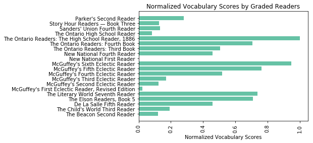

```python
import matplotlib.pyplot as plt
plt.barh(*zip(*normVocabStats.items()))
plt.xticks(rotation=90)
plt.xlabel('Normalized Vocabulary Scores')
plt.title('Normalized Vocabulary Scores by Graded Readers')
plt.show()
```

The vocabulary score results are not very surprising. The highest score is the high school book and the lowest is the first grade reader. The one notable score is the "The Ontario High School Reader". This reader had the third to smallest score.

## 2. After consulting section 3.2 in chapter 1 of Bird-Klein, create a method for scoring the long-word vocabulary size of a text, and likewise normalize (and explain) the scoring as in step 1 above.

The long-word vocabulary size is defined as the number of unique words over a certain length threshold. Expressed in mathematical terms it follows the following condition: $$ {w | w ∈ V & P(w)} $$ For this example, we will use p(w) = len(w) > 10. The score will then be normalized using the following equation:

> $$ f(x) =\ \ \ \ 0 <= \frac{(x- minX)}{(maxX - minX)} <= 1 $$

The same normalization technique was used. This is to ensure a consistent scaling and interpretation.

```python
longWordsStats = {}
for k,v in book_list.items():
    longWordsStats[k] = vocabMeasures(v, 'long_num')
```

```python
normLongStats = {}
maxLong = max(longWordsStats.values())
minLong = min(longWordsStats.values())
normLongStats = {k: (v-minLong) / (maxLong-minLong) for k, v in longWordsStats.items()}
```

```python
for key, value in sorted(normLongStats.items(), key=lambda x: x[1]):
    print("{} : {}".format(key, value))
```

```
McGuffey's Third Eclectic Reader : 0.0
Story Hour Readers — Book Three : 0.007510109763142692
McGuffey's First Eclectic Reader, Revised Edition : 0.012709416522241479
New National First Reader : 0.016753321779318313
The Child's World Third Reader : 0.0340843443096476
McGuffey's Second Eclectic Reader : 0.06759098786828423
The Beacon Second Reader : 0.0681686886192952
Sanders' Union Fourth Reader : 0.1022530329289428
The Ontario High School Reader : 0.10340843443096476
McGuffey's Fourth Eclectic Reader : 0.1877527440785673
Parker's Second Reader : 0.1923743500866551
New National Fourth Reader : 0.2663200462160601
De La Salle Fifth Reader : 0.2848064702484113
The Ontario Readers: Third Book : 0.28827267475447715
McGuffey's Fifth Eclectic Reader : 0.4685153090699018
The Ontario Readers: Fourth Book : 0.5441941074523396
The Literary World Seventh Reader : 0.6626227614095899
McGuffey's Sixth Eclectic Reader : 0.7972270363951474
The Elson Readers, Book 5 : 0.9214326978625073
The Ontario Readers: The High School Reader, 1886 : 1.0
```

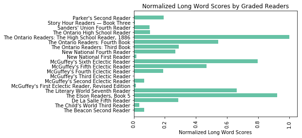

```python
plt.barh(*zip(*normLongStats.items()))
plt.xticks(rotation=90)
plt.xlabel('Normalized Long Word Scores')
plt.title('Normalized Long Word Scores by Graded Readers')
plt.show()
```

The results of the long-word vocabulary size are pretty consistent with the results above. The highest value was the High School Reader and the lowest was the Third Grade Reader. The long-word vocabulary scores are more skewed. The junior high and upper middle school readers tend to have higher values. The lower middle school have quite small values.

## 3. Now create a “text difficulty score” by combining the lexical diversity score from homework 1, and your normalized score of vocabulary size and long-word vocabulary size, in equal weighting. Explain what you see when this score is applied to same graded texts you used in homework 1.

```python
lexDivStats = {}
for k,v in book_list.items():
    lexDivStats[k] = vocabMeasures(v, 'lex_div')
```

```python
diff_score = dict((k, float((1/3)*lexDivStats[k]) + (1/3)* normLongStats[k] + (1/3)*normVocabStats[k]) for k in normVocabStats)
```

```python
for key, value in sorted(diff_score.items(), key=lambda x: x[1]):
    print("{} : {}".format(key, value))
```

[output not shown]

[figure not shown]

```python
plt.barh(*zip(*diff_score.items()))
plt.xticks(rotation=90)
plt.xlabel('Difficulty Scores')
plt.title('Difficulty Scores by Graded Readers')
plt.show()
```

```python
normLexStats = {}
maxLex = max(lexDivStats.values())
minLex = min(lexDivStats.values())
normLexStats = {k: (v-minLex) / (maxLex-minLex) for k, v in lexDivStats.items()}
```

```python
import pandas as pd
df = pd.DataFrame(list(normLexStats.items()), columns=["Title", "NormLexDiversity"])
df['NormLongWords'] = df['Title'].map(normLongStats)
df['normVocabStats'] = df['Title'].map(normVocabStats)
df.head(5)
```

|  | Title | NormLexDiversity | NormLongWords | normVocabStats |
| --- | --- | --- | --- | --- |
| 0 | The Beacon Second Reader | 0.223794 | 0.068169 | 0.120045 |
| 1 | The Child's World Third Reader | 0.096552 | 0.034084 | 0.191516 |
| 2 | De La Salle Fifth Reader | 0.316925 | 0.284806 | 0.459731 |
| 3 | The Elson Readers, Book 5 | 0.000000 | 0.921433 | 0.710608 |
| 4 | The Literary World Seventh Reader | 0.104698 | 0.662623 | 0.736748 |

```python
df2 = pd.melt(df, id_vars = "Title")
df2['Score'] = df2['value']
```

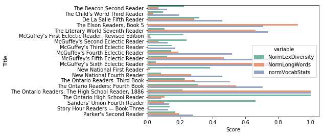

[figure not shown]

```python
import seaborn as sns
fig = plt.figure()
sns.set_palette("Set2")
sns.barplot(x = 'Score', y='Title', hue = 'variable',data=df2)
plt.figure(figsize=(450,100))
plt.title("Comparison of Scores")
plt.show()
```